# Cuadro de Valores

Santoyo Sanchez Francisco Javier

08/03/2021

Naturaleza: El Maíz es un pasto de la familia botánica Poaceae o Gramínea, los antiguos agricultores mesoamericanos se dieron cuenta de que cierta mutación del teosinte (un tipo de Gramínea) era comestible y guardaban la semilla de sus mejores mazorcas para sembrarla y así se pudiera producir este nuevo tipo. Esta planta dentro de ella tiene una parte hembra y una macho, el macho suele tener mas granos de maíz que la hembra, existen dos tipos de Maíz, el blanco y el amarillo.

Valor de uso: El Maíz no solo se utiliza para satisfacer las necesidades de los humanos, también funciona para satisfacer las necesidades de otros seres vivos como son los animales por lo que se apoya con importaciones que en 2017 ascendieron a 14.3 millones de toneladas, y las estimaciones para el año comercial 2017/18 establecen un aumento del 5% más, cerrando en 15.3 millones de toneladas. (SEGOB: 2019)

Valor de cambio: Hoy en día, la producción de Maíz blanco que sirve normalmente para el consumo humano tiene aproximadamente el 86% mientras que en la producción del Maíz amarillo solo se utiliza para la industria o para generar un alimento balanceado en lo agropecuario solo se ocupa el 24% de la producción de este. Los dos estados que producen mas ambos tipos de Maíz son Tamaulipas y Nuevo León. (SEGOB:2019)

Valor: En la economía Mexicana se puede considerar en que el Maiz es el cultivo mas importante que tiene nuestro país como uno de los países que mas exporta maíz asi se lograron exportar 1.6 millones de toneladas de maíz blanco, mismas que tuvieron como destinos: Venezuela (54%), Kenia (35%), Estados Unidos (3%), Sudáfrica (3%), Tanzania (2%) y Guatemala (1%).

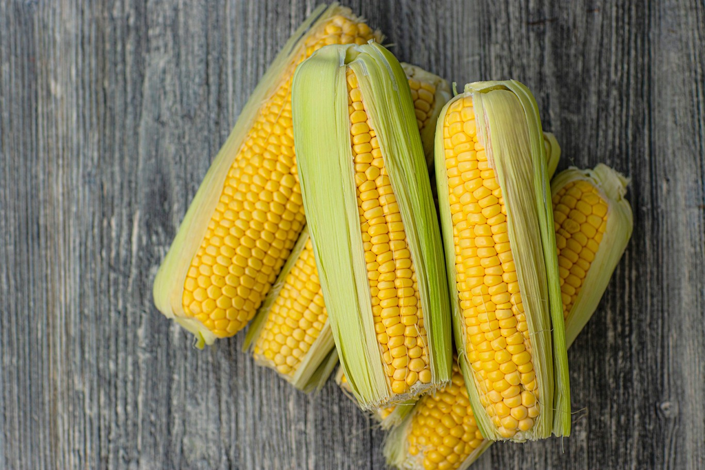

Fuente: Directo al Paladar

## Bibliografía

1. SAGARPA. (2019). Planeación Agrícola Nacional.
2. SEGOB. (2019). EL maíz, un grano con mucho valor.